# Homework_1

Di Zhang 118020518

9/8/2019

# Q1:perform data check on the DJ Index data.

## read DJ Index data:

```r
dj=read.csv('/Users/zhangdi/FIN 3380/Homework/HW1/dj.csv')
dj$X=NULL
print(head(dj))
```

```
##         date   dji
## 1 1896-05-26 40.94
## 2 1896-05-27 40.58
## 3 1896-05-28 40.20
## 4 1896-05-29 40.63
## 5 1896-06-01 40.60
## 6 1896-06-02 40.04
```

### performing data check:

#### Plot the dji

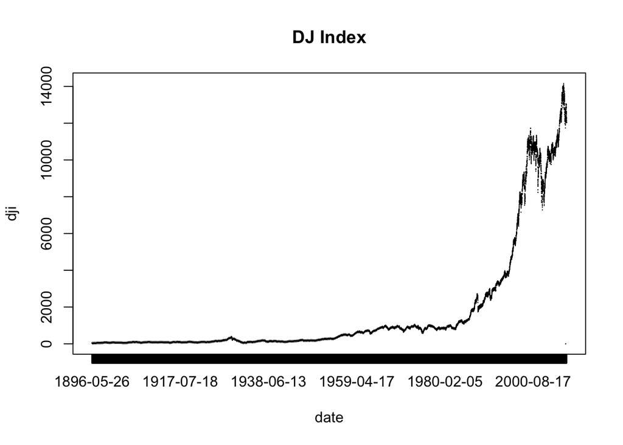

```r
plot(dj$dji~dj$date,type='l',ylab='dji',xlab='date',main='DJ Index')
```

#### Check the dimention of data:

```r
print(dim(dj))
```

```
## [1] 28073     2
```

#### Outputing summary statistics:

```r
print(summary(dj))
```

```
##          date            dji
##  1896-05-26:    1   Min.   :    0.00
##  1896-05-27:    1   1st Qu.:   98.03
##  1896-05-28:    1   Median :  284.64
##  1896-05-29:    1   Mean   : 1669.66
##  1896-06-01:    1   3rd Qu.:  964.76
##  1896-06-02:    1   Max.   :14164.53
##  (Other)   :28067   NA's   :1
```

##### from the summary, we can see there is a data problem: the min of dji is 0 and there is one NA.

##### use a package.

```r
library(dplyr)
library(zoo)
```

##### so we use basic data manipulation to fix the data problem.

```r
dj=dj[-which(dj$dji==0),]
dj=dj %>% arrange(date) %>%
  filter(!is.na(dji))
print(summary(dj))
```

```
##          date            dji
##  1896-05-26:    1   Min.   :   28.66
##  1896-05-27:    1   1st Qu.:   98.03
##  1896-05-28:    1   Median :  284.71
##  1896-05-29:    1   Mean   : 1669.72
##  1896-06-01:    1   3rd Qu.:  964.77
##  1896-06-02:    1   Max.   :14164.53
##  (Other)   :28065
```

# Q2

## (A) use Logarithmic return

### read AAPL & MSFT

```r
aapl=read.csv('/Users/zhangdi/FIN 3380/Homework/HW1/aapl.csv')
msft=read.csv('/Users/zhangdi/FIN 3380/Homework/HW1/msft.csv')
aapl$X=NULL
msft$X=NULL
print(head(aapl))
```

```
##   permno       date   bidlo  askhi openprc    prc      vol
## 1  14593 2015-01-02 107.350 111.44  111.39 109.33 53204828
## 2  14593 2015-01-05 105.410 108.65  108.29 106.25 64289001
## 3  14593 2015-01-06 104.630 107.43  106.54 106.26 65797116
## 4  14593 2015-01-07 106.695 108.20  107.20 107.75 40106644
## 5  14593 2015-01-08 108.700 112.15  109.23 111.89 59364547
## 6  14593 2015-01-09 110.210 113.25  112.67 112.01 53699527
```

```r
print(head(msft))
```

```
##   permno       date bidlo   askhi openprc    prc      vol
## 1  10107 2015-01-02 46.54 47.4200   46.66 46.760 27913852
## 2  10107 2015-01-05 46.25 46.7300   46.37 46.325 39673865
## 3  10107 2015-01-06 45.54 46.7490   46.38 45.650 36447854
## 4  10107 2015-01-07 45.49 46.4600   45.98 46.230 29222067
## 5  10107 2015-01-08 46.72 47.7499   46.75 47.590 29645202
## 6  10107 2015-01-09 46.90 47.8200   47.61 47.190 23944181
```

#### calculate return of aapl

```r
aaplret=aapl %>% select(date,prc) %>%
  arrange(date) %>%
  mutate(prc.lag=lag(prc,1)) %>%
  mutate(return1=prc/prc.lag) %>%
  mutate(aaplret=log(return1)) %>%
  select(date,aaplret)
aaplret$date=as.Date(aaplret$date)
print(head(aaplret))
```

```
##         date       aaplret
## 1 2015-01-02            NA
## 2 2015-01-05 -2.857604e-02
## 3 2015-01-06  9.413332e-05
## 4 2015-01-07  1.392479e-02
## 5 2015-01-08  3.770251e-02
## 6 2015-01-09  1.071932e-03
```

#### calculate return of msft

```r
msftret=msft %>% select(date,prc) %>%
  arrange(date) %>%
  mutate(prc.lag=lag(prc,1)) %>%
  mutate(return1=prc/prc.lag) %>%
  mutate(msftret=log(return1)) %>%
  select(date,msftret)
msftret$date=as.Date(msftret$date)
print(head(msftret))
```

```
##         date      msftret
## 1 2015-01-02           NA
## 2 2015-01-05 -0.009346312
## 3 2015-01-06 -0.014678148
## 4 2015-01-07  0.012625288
## 5 2015-01-08  0.028993730
## 6 2015-01-09 -0.008440682
```

#### merge aapl and msft

```r
msft.aapl=aaplret %>% inner_join(msftret,by="date")
print(head(msft.aapl))
```

```
##         date       aaplret      msftret
## 1 2015-01-02            NA           NA
## 2 2015-01-05 -2.857604e-02 -0.009346312
## 3 2015-01-06  9.413332e-05 -0.014678148
## 4 2015-01-07  1.392479e-02  0.012625288
## 5 2015-01-08  3.770251e-02  0.028993730
## 6 2015-01-09  1.071932e-03 -0.008440682
```

#### relative performance

```r
msft.aapl=msft.aapl %>% mutate(msft.aapl.ret=msftret-aaplret)
print(summary(msft.aapl$msft.aapl.ret))
```

```
##       Min.    1st Qu.     Median       Mean    3rd Qu.       Max.
## -0.0900589 -0.0061452  0.0004704  0.0004136  0.0073185  0.0947198
##       NA's
##          1
```

#### cumulative performance

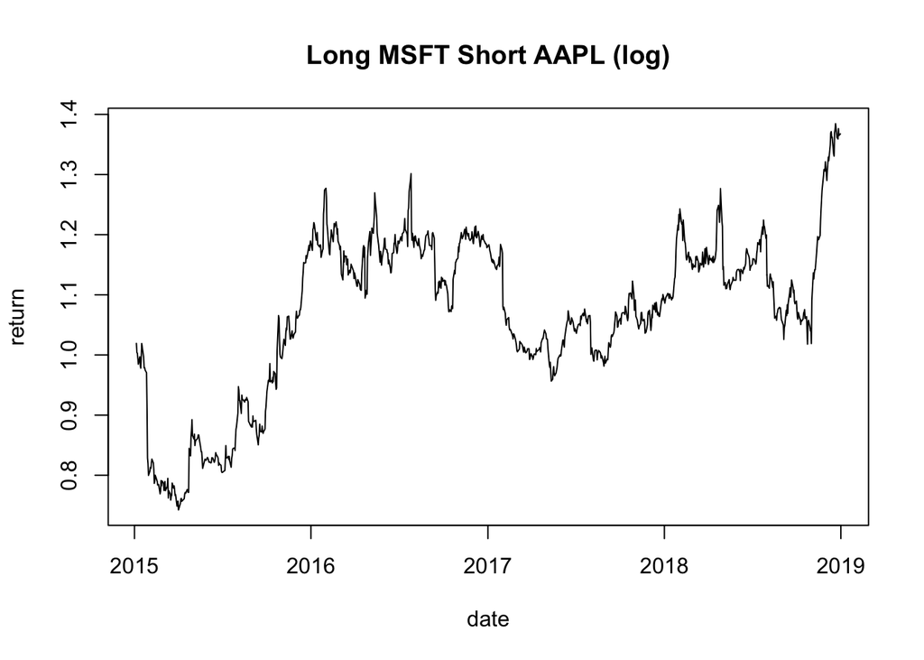

```r
msft.aapl=msft.aapl %>% arrange(date) %>%
  filter(!is.na(msft.aapl.ret)) %>%
  mutate(cumret=cumprod(msft.aapl.ret+1))
plot(msft.aapl$cumret~as.Date(msft.aapl$date),type='l',ylab='return',xlab='date',main='Long MSFT Short AAPL (log)')
```

#### performance by using arithmatic method

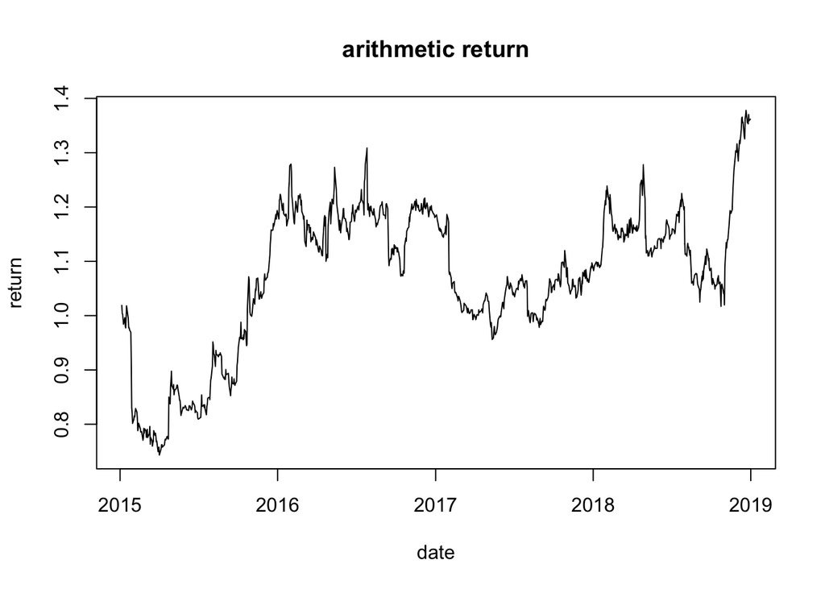

```r
arith.aaplret=aapl %>% select(date,prc) %>%
  arrange(date) %>%
  mutate(prc.lag=lag(prc,1)) %>%
  mutate(arith.aaplret=prc/prc.lag-1) %>%
  select(date,arith.aaplret)
arith.aaplret$date=as.Date(arith.aaplret$date)
arith.msftret=msft %>% select(date,prc) %>%
  arrange(date) %>%
  mutate(prc.lag=lag(prc,1)) %>%
  mutate(arith.msftret=prc/prc.lag-1) %>%
  select(date,arith.msftret)
arith.msftret$date=as.Date(arith.msftret$date)
arith.msft.aapl=arith.aaplret %>% inner_join(arith.msftret,by="date")
arith.msft.aapl=arith.msft.aapl %>% mutate(arith.msft.aapl.ret=arith.msftret-arith.aaplret) %>%
  filter(!is.na(arith.msft.aapl.ret)) %>%
  mutate(cumret=cumprod(arith.msft.aapl.ret+1))
plot(arith.msft.aapl$cumret~as.Date(arith.msft.aapl$date),type='l',ylab='return',xlab='date',main='arithmetic return')
```

#### difference between logarithmic and average:

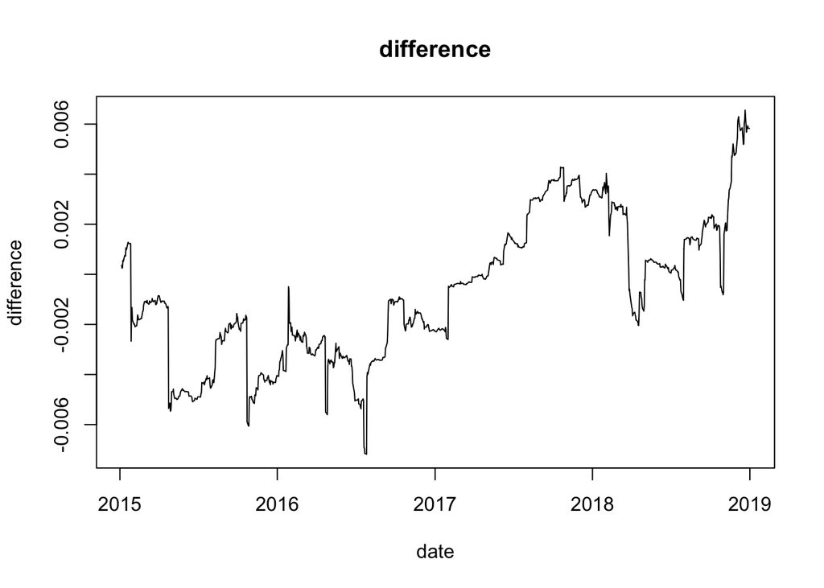

```r
dif=data.frame('date'=arith.msft.aapl$date,'log.ret'=msft.aapl$cumret,'arith.ret'=arith.msft.aapl$cumret)
dif=dif %>% mutate(difference=dif$log.ret-dif$arith.ret)
plot(dif$difference~as.Date(dif$date),type='l',ylab='difference',xlab='date',main='difference')
```

## (B) plot two lines on the same chart

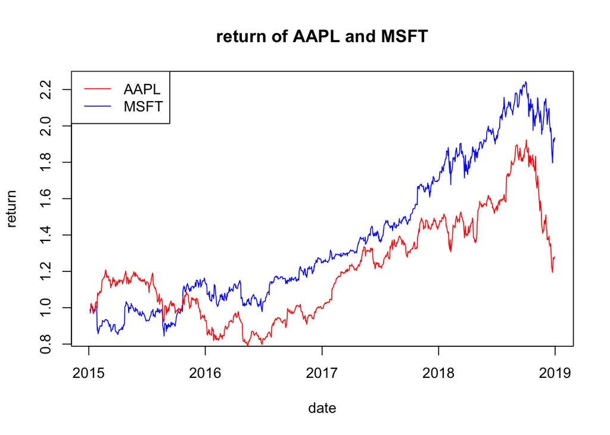

```r
aaplret=aaplret %>% arrange(date) %>%
  filter(!is.na(aaplret)) %>%
  mutate(aaplcumret=cumprod(aaplret+1))
msftret=msftret %>% arrange(date) %>%
  filter(!is.na(msftret)) %>%
  mutate(msftcumret=cumprod(msftret+1))
plot(msftret$msftcumret~as.Date(msftret$date),col='blue',type='l',ylab='return',xlab='date',main='return of AAPL and MSFT')
lines(aaplret$aaplcumret~as.Date(aaplret$date),col='red')
legend('topleft',c('AAPL','MSFT'),lty=c(1,1),col=c('red','blue'))
```

## (C) Amend the stategy

#### insert a new column

```r
msft.aapl=msft.aapl %>% arrange(date) %>%
  mutate(mysignal=ifelse(msft.aapl.ret>0,1,-1))
```

#### if the signal of the last day is 1, the return of today is the same as the original one, if the signal of the last day is -1, the return of today is the opposite number of the original one.

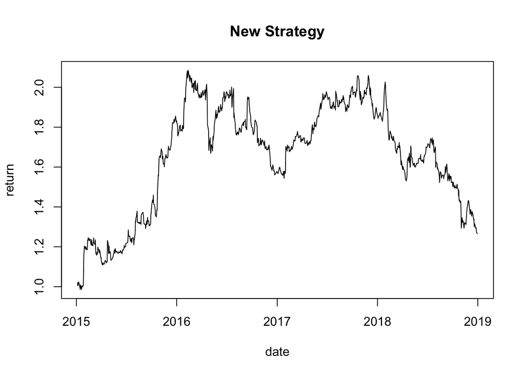

```r
msft.aapl=msft.aapl %>% arrange(date) %>%
  mutate(newsignal=lag(mysignal,1))
msft.aapl$newsignal[1]=1
msft.aapl=msft.aapl %>% arrange(date) %>%
  mutate(newret=msft.aapl.ret*newsignal) %>%
  mutate(newcum=cumprod(newret+1))
plot(msft.aapl$newcum~as.Date(msft.aapl$date),type='l',ylab='return',xlab='date',main='New Strategy')
```

#### conclusion: The new strategy is good at the middle of the whole period cause the return is larger than 1.4 at most of time, but at last the total return is 1.27, less than 1.37, so at last it is not so good.

# Q3

#### Function: return a dataframe with 4 columns as in the sample in class: that is prc, avg, sd2up, sd2down

```r
Bollinger_Band=function(x,window) {
  bb=data.frame(x)
  bb=bb %>% mutate(avg=rollmean(x,k=window,fill=NA,align='right'),
                   sd=rollapply(x,width=window,FUN=sd,na.rm=T,fill=NA,align='right')) %>%
    mutate(sd2up=avg+2*sd,sd2down=avg-2*sd) %>%
    select(x,avg,sd2up,sd2down)
  return(bb)
}
```

#### Apply the function to MSFT with a window of 15 days. Plot results on MSFT.

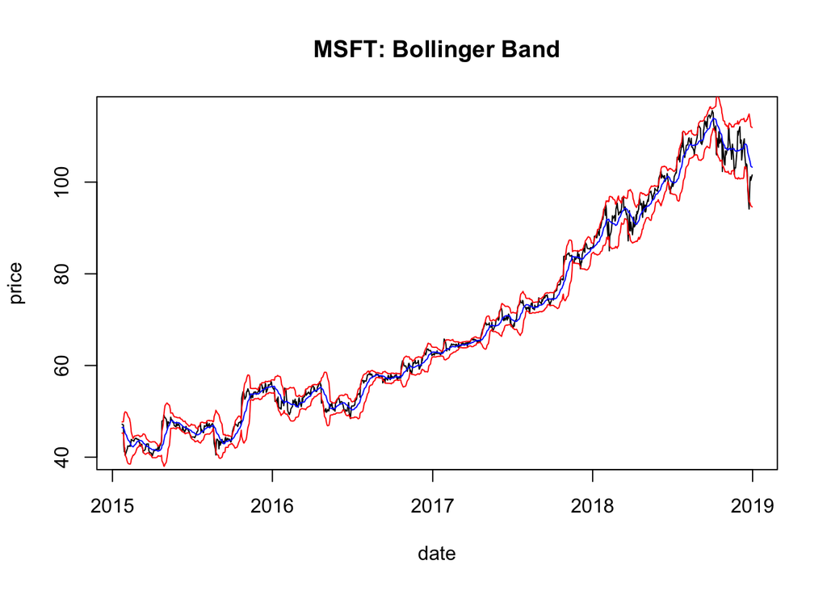

```r
bb=Bollinger_Band(msft$prc,15)
bb['date']=msft$date
bb$date=as.Date(bb$date)
bb=bb %>% filter(!is.na(bb$avg))
plot(bb$x~bb$date,type='l',ylab='price',xlab='date',main='MSFT: Bollinger Band')
lines(bb$avg~bb$date,col='blue')
lines(bb$sd2up~bb$date,col='red')
lines(bb$sd2down~bb$date,col='red')
```